# Feature Engineering

## Feature Engineering

This report documents the feature engineering process applied to a dataset. It follows on from previous reports on Exploratory Data Analysis and Data Cleaning, starting with a clean dataset of 15,000 data points. We explore transformations, feature interactions, and dimensionality reduction with emphasis firstly on model interpretability, and secondly on predictive accuracy while addressing skewness, multicollinearity, and non-linear relationships. While some other regression techniques have less strict assumptions, this report focuses on linear regression to demonstrate the widest range of engineering techniques.

```python
import numpy as np
import pandas as pd
import seaborn as sns
import matplotlib.pyplot as plt
import matplotlib.colors as mcolors
from sklearn.pipeline import Pipeline
from sklearn.compose import ColumnTransformer, make_column_transformer, TransformedTargetRegressor
from sklearn.decomposition import PCA
from sklearn.preprocessing import FunctionTransformer, OneHotEncoder, StandardScaler, PowerTransformer
from sklearn.linear_model import LinearRegression
from sklearn.base import BaseEstimator, TransformerMixin
from sklearn.model_selection import cross_val_score
from IPython.display import Markdown
from scipy import stats
from sklearn.metrics import r2_score
from scipy.special import inv_boxcox
from statsmodels.tools.tools import add_constant
from statsmodels.stats.outliers_influence import variance_inflation_factor
import statsmodels.api as sm
# TransformedTargetRegressor is raising unnecessary warnings
import warnings
warnings.filterwarnings('ignore', category=UserWarning)


# load data
df = pd.read_csv('feature_eng_calories.csv')

# pipelines will rename database columns. To give them more presentable names we will add
# feature_aliases as we go.
feature_aliases = {}
```

### Initial Data Assessment

#### Target and Feature Distributions

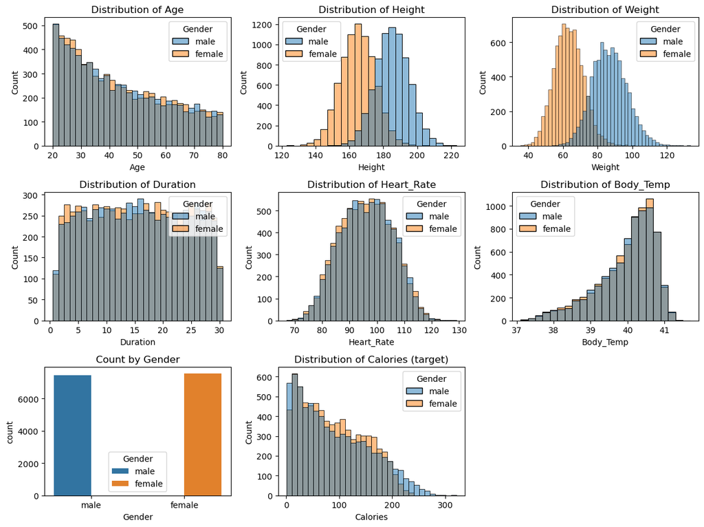

```python
import matplotlib.pyplot as plt
import pandas as pd
import numpy as np
import seaborn as sns

class PlotGrid:
    """
    A class to simplify the creation and management of a grid of subplots.
    """
    def __init__(self, n_plots, n_cols=3, row_height=3):
        """
        Initializes the plot grid.

        Args:
            n_cols (int): The number of columns in the grid.
            n_plots (int): The total number of plots in the grid.
            row_height (int): Row height in inches.
        """
        self.n_cols = n_cols
        self.n_plots = n_plots
        self.row_height = row_height
        self.n_rows = self.calculate_rows()
        self.fig, self.axes = plt.subplots(self.n_rows, self.n_cols, figsize=(12, self.row_height
            * self.n_rows))

        # Flatten the axes for easy indexing
        self.axes = self.axes.flatten()

    def calculate_rows(self):
        return (self.n_plots + self.n_cols - 1) // self.n_cols

    def get_axis(self, index):
        """
        Returns the matplotlib Axes object at a given index.

        Args:
            index (int): The 0-based index of the subplot.

        Returns:
            matplotlib.axes.Axes: The Axes object for plotting.
        """
        if index >= len(self.axes):
            raise IndexError("Index out of bounds for the number of subplots.")
        return self.axes[index]

    def delete_unused_axes(self):
        """
        Deletes any axes that were not used for plotting.
        """
        for j in range(self.n_plots, len(self.axes)):
            self.fig.delaxes(self.axes[j])

    def show(self):
        """
        Delates_unused axes, adjusts the layout and displays the plot.
        """
        self.delete_unused_axes()
        plt.tight_layout()
        plt.show()

# plot numerical features and set bin widths manually based on range of observations
cols_and_widths = [('Age', 2), ('Height', 4), ('Weight', 2), ('Duration', 1), ('Heart_Rate', 2),
    ('Body_Temp', 0.2)]

# create a grid of 3 columns for 8 plots
grid = PlotGrid(n_cols=3, n_plots=8)

for i, col_and_width in enumerate(cols_and_widths):
    col, bin_width = col_and_width
    axis = grid.get_axis(i)
    sns.histplot(
        data=df,
        x=col,
        hue='Gender', # superimpose separate plots for Gender
        alpha=0.5, # transparency for superimposed plots
        binwidth=bin_width,
        ax=axis,
        # 'Duration' is conceptually continuous but rounded to integer values. This causes the last bin
        # to include the upper AND lower values. discrete = True rectifies this
        discrete = col=='Duration',
    )
    axis.set_title(f'Distribution of {col}')

# plot categorical feature 'Gender'
sns.countplot(
    data=df,
    x='Gender',
    hue='Gender',
    ax=grid.get_axis(6),
)
grid.get_axis(6).set_title('Count by Gender')

# plot 'Calories' last
sns.histplot(
        data=df,
        x='Calories',
        hue='Gender',
        alpha=0.5,
        binwidth=10,
        ax=grid.get_axis(7),
    )
grid.get_axis(7).set_title(f'Distribution of Calories (target)')
grid.show()
```

We can observe from the plots that `Height`, `Weight` and `Heart_Rate` appear to be normally distributed. `Duration` is fairly uniformly distributed (symmetrical). `Body_Temp` is left skewed, `Age` and `Calories` (target) are right skewed. `Gender` is well balanced ie observations of **male** and **female** are approximately equal.

#### Scatterplots of Features vs Target

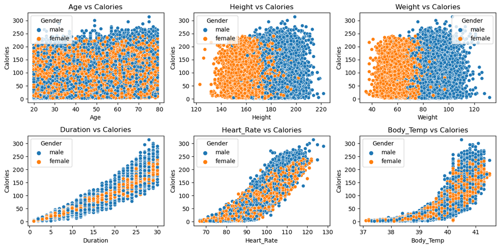

```python
features = ['Age', 'Height', 'Weight', 'Duration', 'Heart_Rate', 'Body_Temp']

grid = PlotGrid(len(features))

for i, feature in enumerate(features):
    axis = grid.get_axis(i)
    sns.scatterplot(x=df[feature], y=df['Calories'], hue=df['Gender'], ax=axis)
    axis.set_title(f"{feature} vs {'Calories'}")
    axis.set_xlabel(feature)
    axis.set_ylabel('Calories')

grid.show()
```

The scatterplots reveal evidence of heteroscedasticity of `Calories` with respect to `Duration`, `Heart_Rate` and `Body_Temp`. There's no obvious evidence of relationships between `Age`, `Height` or `Weight` and the target but `Height` and `Weight` do appear to be related to `Gender`. To address the problem of heteroscedasticity it is common practice to transform the target variable in order to stabilise variance.  
Skewed variables often exhibit heteroscedasticity and symmetric distributions tend to stabilize variance. Since `Body_Temp` is skewed it is best practice to address this before transforming the target. `Age` is right skewed, and although `Age` doesn't appear to have a strong relationship with the target it may have *some* predictive power so it is best practice to apply a transformation to rectify this.

#### Correlations

A correlation matrix shows the pairwise Pearson correlation coefficients for a set of variables. `Gender` is a binary categorical feature. In order to include `Gender` in correlations (and subsequently in linear regression models) we need to encode this categorical feature. Binary encoding will encode **female/male** as **0/1**.

```python
# All numerical values will be standard scaled
scale_cols = ['Age', 'Height', 'Weight', 'Duration', 'Body_Temp', 'Heart_Rate']
preprocessor = ColumnTransformer([
    ('cat', OneHotEncoder(drop='if_binary', dtype=int, sparse_output=False), ['Gender']),
    ('num', StandardScaler(), scale_cols),]
    ).set_output(transform="pandas") # outputs pandas dataframe with informative column names

one_hot_pipeline = Pipeline([
    ('preprocessor', preprocessor),
    ('regression', LinearRegression()),
])

X = df.copy()
y = X.pop('Calories')
X_transformed = one_hot_pipeline.named_steps['preprocessor'].fit_transform(X) # skip the regression step, output the transformed data

# more presentable column names
feature_aliases.update({'num__Duration': 'Duration',
                   'num__Heart_Rate': 'Heart_Rate',
                   'num__Weight': 'Weight',
                   'cat__Gender_male': 'Gender_male',
                   'num__Height': 'Height',
                   'num__Body_Temp': 'Body_Temp',
                   'num__Age': 'Age'})
```

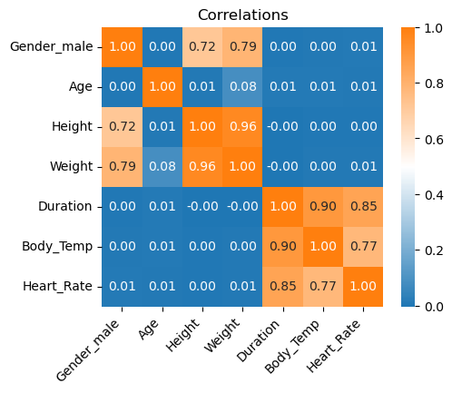

```python
custom_cmap = mcolors.LinearSegmentedColormap.from_list("custom",
    ["#1f77b4", "white", "#ff7f0e"])

def plot_correlation_matrix(dataframe):
    """
    Plots a correlation matrix.

    Args:
        dataframe (pd.DataFrame): Input DataFrame
    """

    # we've added const columns in order to use sm.OLS. This is irrelevant to corrrelation matrix, so drop if exists
    dataframe = dataframe.drop(columns=['const'], errors='ignore')
    # more presentable column names
    dataframe = dataframe.rename(columns=feature_aliases)
    plt.figure(figsize=(5, 4))
    sns.heatmap(dataframe.corr(), annot=True,
            cmap=custom_cmap,
            fmt=".2f")
    plt.title("Correlations")
    plt.xticks(rotation=45, ha='right')
    plt.show()

def score_model(X, y, pipeline):
    """
    calculates 5-fold cross-validated r2 and RMSE means and std's of a LinearRegression

    Args:
        X (pd.DataFrame): Input dataframe of features
        y (pd.Series): Input target
        pipeline (sklearn.pipeline.Pipeline): pipeline including preprocessor and regressor

    Returns:
        Tuple: tuple containing:
            - 'r2_mean' (float): mean R² score
            - 'r2_std' (float): R² std
            - 'rmse' (float): mean Root Mean Squared Error
            - 'rmse_std' (float): Root Mean Squared Error std

    """

    r2_scores = cross_val_score(
        pipeline,
        X, y,
        cv=5,
        scoring="r2",
    )
    rmse_scores = cross_val_score(
        pipeline,
        X, y,
        cv=5,
        scoring="neg_mean_squared_error",
    )
    return (r2_scores.mean(), r2_scores.std(), rmse_scores.mean(), rmse_scores.std())


plot_correlation_matrix(X_transformed)
```

The correlation matrix reveals that there is evidence of linear relationships between `Duration`, `Heart_Rate` and `Body_Temp`, and also between `Height` and `Weight`, which we will address later in the report.

### Baseline Model

As we develop our model we will use cross-validated R-squared and RMSE metrics, feature coefficients and corresponding p-values, and VIFs of a linear regression to evaluate our transformations. With this in mind it will be useful to score the model before applying transformations in order to have a baseline.  
It is best practice to standard scale the features beforehand so that coefficients can be meaningfully compared. This can also improve model performance.

```python
def display_scores(X, y, pipeline):
    """
    displays a table of metrics for a regression on a transformed dataframe

    Args:
        X (pd.DataFrame): Input dataframe of features
        y (pd.Series): Input target
        pipeline (sklearn.pipeline.Pipeline): pipeline including preprocessor and regressor

    """
    scores = score_model(X, y, pipeline)
    scores_df = pd.DataFrame([scores], columns=['R-squared', 'R-squared std', 'RMSE', 'RMSE std'])
    display(Markdown('''#### Cross-Validated Performance Metrics (5-Fold)'''))
    display(scores_df.style.hide(axis="index"))

display_scores(X, y, one_hot_pipeline)
```

Cross-Validated Performance Metrics (5-Fold)

| R-squared | R-squared std | RMSE | RMSE std |
| --- | --- | --- | --- |
| 0.964152 | 0.001236 | -139.744512 | 4.722011 |

```python
# we will use statsmodels.OLS to get coefficients and p-values
def display_coefs(X, y):
    """
    calculates coefficients, p-values and VIFs for a regression model using statsmodels.OLS
    and displays in table form

    Args:
        X (pd.DataFrame): Input dataframe of features
        y (pd.Series): Input target

    """
    display(Markdown('''#### Linear Regression Coefficients'''))
    # OLS needs an extra column for the intercept
    X = sm.add_constant(X, prepend=True)
    X = X.rename(columns=feature_aliases)
    ols_model = sm.OLS(y, X)
    results = ols_model.fit()
    results_df = pd.DataFrame({'Coeff': results.params, 'P-values': results.pvalues}).sort_values(
        by='Coeff', ascending=False, key=abs)

    vifs = [variance_inflation_factor(X.values, i) for i in range(1, X.shape[1])]
    results_df['VIF'] =  pd.Series([np.nan] + vifs, index=X.columns)
    display(results_df)

display_coefs(X_transformed, y)
```

Linear Regression Coefficients

|  | Coeff | P-values | VIF |
| --- | --- | --- | --- |
| const | 90.356996 | 0.000000e+00 | NaN |
| Duration | 55.723385 | 0.000000e+00 | 7.778497 |
| Heart_Rate | 18.634575 | 0.000000e+00 | 3.667896 |
| Body_Temp | -13.346257 | 0.000000e+00 | 5.278884 |
| Age | 8.055571 | 0.000000e+00 | 1.107121 |
| Weight | 5.627602 | 1.648266e-41 | 18.557864 |
| Height | -3.545610 | 2.754280e-22 | 14.275359 |
| Gender_male | -1.648110 | 3.901637e-07 | 2.830109 |

Residual Plots

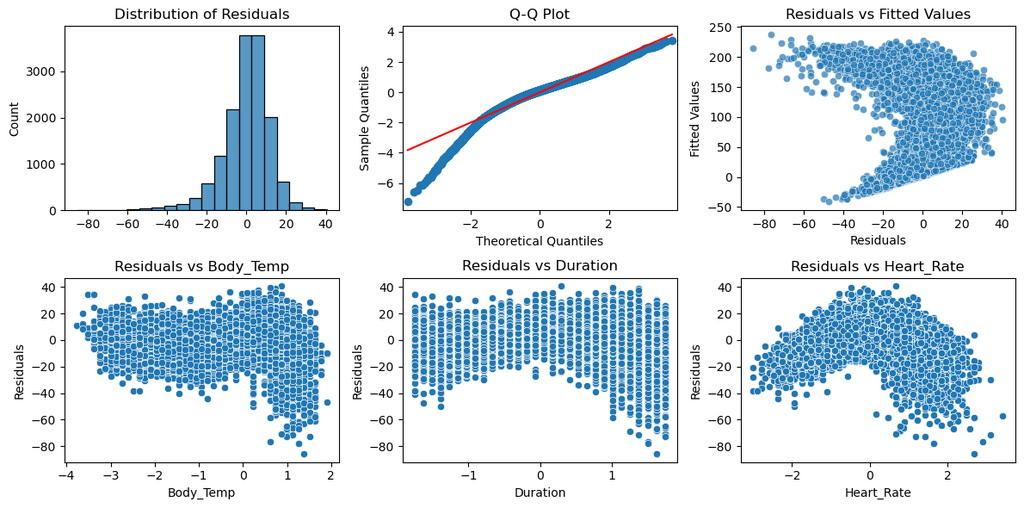

```python
def residual_plots(X, y, features):
    """
    calculates residuals for a regression model using statsmodels.OLS
    and plots: Distribution of Residuals
               QQ-plot
               Residuals vs Fitted Values
               Residuals vs feature for a list of features

    Args:
        X (pd.DataFrame): Input dataframe of features
        y (pd.Series): Input target
        features (list): list of columns in X

    """
    display(Markdown('''#### Residual Plots'''))
    X = sm.add_constant(X, prepend=True)
    ols_model = sm.OLS(y, X)
    results = ols_model.fit()
    y_pred = results.predict(X)
    residuals = y_pred - y

    grid = PlotGrid(n_plots=6)
    sns.histplot(residuals,
        ax=grid.get_axis(0),
        bins=20,
        )
    grid.get_axis(0).set_title('Distribution of Residuals')

    sm.qqplot(residuals, line='s', fit=True, ax=grid.get_axis(1)) # 's' for standardized line, 'fit=True' uses sample mean/std
    grid.get_axis(1).set_title('Q-Q Plot')


    sns.scatterplot(x=residuals, y=y_pred, alpha=0.7, ax=grid.get_axis(2))
    grid.get_axis(2).set_title('Residuals vs Fitted Values')
    grid.get_axis(2).set_ylabel('Fitted Values')
    grid.get_axis(2).set_xlabel('Residuals')

    for i, feature in enumerate(features):
        axis = grid.get_axis(i+3)
        name = feature_aliases.get(feature)
        sns.scatterplot(x=X[feature], y=residuals,  ax=axis)
        axis.set_title(f'Residuals vs {name}')
        axis.set_ylabel('Residuals')
        axis.set_xlabel(name)

    grid.show()

residual_plots(X_transformed, y, ['num__Body_Temp', 'num__Duration', 'num__Heart_Rate'])
```

The distribution of residuals show a left skewed distribution, with more observations of larger negative values than would be expected from a normal distribution. The Q-Q plot shows the quantiles of the residuals vs the quantiles of a normal distribution. This again suggests deviation from normality. The plots of Residuals vs Fitted Values, `Body_Temp`, `Duration` and `Heart_Rate` all show non-random patterns which suggest non-normality of distributions and non-linear relationships beween features and target.

### Target and Feature Transformations

The first steps in feature engineering are target and variable transformations. The aim of these is to address non-normality and heteroscedasticity.

`Body_Temp` is left skewed. Potential transformations for such a feature are log reflected and Box-Cox  
We will test these transformations to find out which is the most suitable.

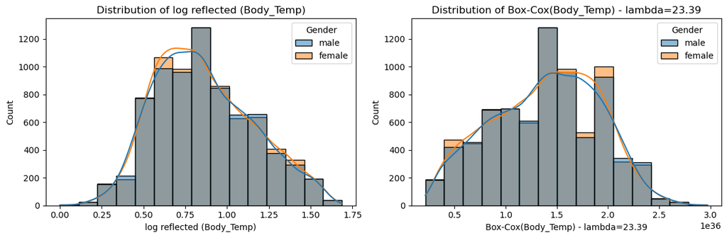

```python
# create an extended dataframe with columns for the transformations we want to try
X_extended = df.copy()
X_extended['log_reflected_body_temp'] = np.log(X_extended['Body_Temp'].max() + 1 - X_extended['Body_Temp'])
X_extended['boxcox_body_temp'], body_temp_lambda = stats.boxcox(X_extended['Body_Temp'])

grid = PlotGrid(n_plots=2, n_cols=2, row_height=4)

plots = [('log_reflected_body_temp', 'log reflected (Body_Temp)'),
         ('boxcox_body_temp', f'Box-Cox(Body_Temp) - lambda={body_temp_lambda:.2f}')]
for i, plot in enumerate(plots):
    axis = grid.get_axis(i)
    col, title = plot
    sns.histplot(
        data=X_extended,
        x=col,
        ax=axis,
        hue='Gender',
        bins=15,
        kde=True,
    )
    axis.set_title(f'Distribution of {title}')
    axis.set_xlabel(f'{title}')

grid.show()
```

Both transformations look useful in normalising the distribution of `Body_Temp`.  
`Age` is right skewed so potential transformations are log, square-root and Box-Cox.

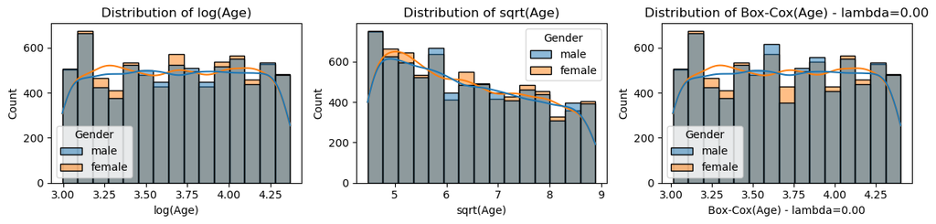

```python
X_extended['log_Age'] = np.log(X_extended['Age'])
X_extended['sqrt_Age'] = np.sqrt(X_extended['Age'])
X_extended['boxcox_Age'], age_lambda = stats.boxcox(X_extended['Age'])

plots = [('log_Age', 'log(Age)'),
         ('sqrt_Age', 'sqrt(Age)'),
         ('boxcox_Age', f'Box-Cox(Age) - lambda={age_lambda:.2f}')]

grid = PlotGrid(len(plots))

for i, plot in enumerate(plots):
    axis = grid.get_axis(i)
    col, title = plot
    sns.histplot(
        data=X_extended,
        x=col,
        ax=axis,
        hue='Gender',
        bins=15,
        kde=True,
    )
    axis.set_title(f'Distribution of {title}')
    axis.set_xlabel(title)

grid.show()
```

Both log and Box-Cox transformations look useful. The lambda value of **0.00** signifies that this Box-Cox transformation *is* the log transformation, so we will log transform `Age`.  
`Calories` is also right skewed.

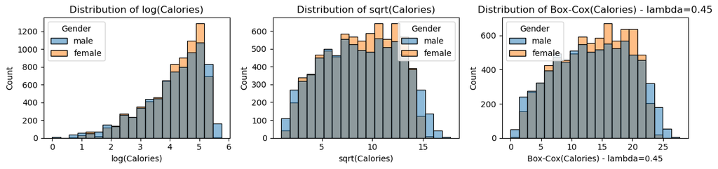

```python
X_extended['sqrt_Calories'] = np.sqrt(X_extended['Calories'])
X_extended['log_Calories'] = np.log(X_extended['Calories'])
X_extended['boxcox_Calories'], target_lambda = stats.boxcox(X_extended['Calories'])

plots = [('log_Calories', 'log(Calories)'),
         ('sqrt_Calories', 'sqrt(Calories)'),
         ('boxcox_Calories', f'Box-Cox(Calories) - lambda={target_lambda:.2f}')]

grid = PlotGrid(len(plots))

for i, plot in enumerate(plots):
    axis = grid.get_axis(i)
    col, title = plot
    sns.histplot(
        data = X_extended,
        x=col,
        ax=axis,
        hue='Gender',
        bins=20,
    )
    axis.set_title(f'Distribution of {title}')
    axis.set_xlabel(title)

grid.show()
```

The square-root and Box-Cox transformations both look useful in normalising `Calories`. We have determined the transformation we will use for `Age` but we also have two options for `Body_Temp`, so we will evaluate linear regression models for combinations of transformations for `Calories` and `Body_Temp` and compare.

```python
def reflected_log(x):
    """
    calculates reflected log values of input array

    Args:
        x (np.ndarray): A 1-dimensional array of floats.

    Returns:
        np.ndarray

    """
    return np.log(np.max(x) + 1 - x)

boxcox_transformer = Pipeline([
    ('boxcox', PowerTransformer(method='box-cox')),
    ('scaler', StandardScaler()),
])

log_reflected_transformer = Pipeline([
    ('log', FunctionTransformer(reflected_log)),
    ('scaler', StandardScaler()),
])

age_pipeline = Pipeline([
    ('log', FunctionTransformer(func=np.log, inverse_func=np.exp)),
    ('scaler', StandardScaler())
])

cat_pipeline = Pipeline([
    ('encoder', OneHotEncoder(drop='if_binary', dtype=int, sparse_output=False))
])

boxcox_target_regressor = TransformedTargetRegressor(regressor=LinearRegression(),
    transformer=PowerTransformer(method='box-cox'))

sqrt_target_regressor = TransformedTargetRegressor(regressor=LinearRegression(),
    func=np.sqrt,
    inverse_func=np.square)

scores = []
X = df.copy()
y = X.pop('Calories')

for transform_name, body_temp_transformation in [('Box-Cox', boxcox_transformer), ('Log reflected', log_reflected_transformer)]:
    for target_transform_name, transformed_target_regressor in [('Box-Cox', boxcox_target_regressor),
            ('sqrt', sqrt_target_regressor)]:
        preprocessor = ColumnTransformer([
            ('body_temp', body_temp_transformation, ['Body_Temp']),
            ('log', age_pipeline, ['Age']),
            ('scaled', StandardScaler(), ['Duration', 'Heart_Rate', 'Height', 'Weight']),
            ('cat', cat_pipeline, ['Gender'])],
            remainder='drop').set_output(transform="pandas")

        pipeline = Pipeline([
            ('preprocessor', preprocessor),
            ('regression', transformed_target_regressor),
        ])
        r2_mean, r2_std, rmse_mean, rmse_std  = score_model(X, y, pipeline)
        scores.append((transform_name, target_transform_name, r2_mean, r2_std, -rmse_mean, rmse_std))

scores_df = pd.DataFrame(scores, columns=['Body_Temp transformation', 'Target Transformation', 'R-squared', 'R-squared std', 'RMSE', 'RMSE std'])
display(Markdown('''#### Cross-Validated Performance Metrics (5-Fold)'''))
display(scores_df.style.hide(axis="index"))
```

Cross-Validated Performance Metrics (5-Fold)

| Body_Temp transformation | Target Transformation | R-squared | R-squared std | RMSE | RMSE std |
| --- | --- | --- | --- | --- | --- |
| Box-Cox | Box-Cox | 0.978404 | 0.001069 | 84.147965 | 3.154050 |
| Box-Cox | sqrt | 0.980334 | 0.000752 | 76.652708 | 2.531216 |
| Log reflected | Box-Cox | 0.977695 | 0.002205 | 86.799195 | 6.621380 |
| Log reflected | sqrt | 0.980078 | 0.001138 | 77.612103 | 3.316441 |

The square root transformation yielded optimal model accuracy for the target variable.  
For `Body_Temp`, the Box-Cox transformation (**λ=23.39**) marginally improved model accuracy compared to log reflected.  
Our data transformation will now include sqrt(`Calories`), Box_Cox(`Body_Temp`) and log(`Age`).  
We will now fit a linear regression model on the transformed data and investigate the residuals.

```python
preprocessor = ColumnTransformer([
        ('boxcox', boxcox_transformer, ['Body_Temp']),
        ('log', age_pipeline, ['Age']),
        ('num', StandardScaler(), ['Duration', 'Heart_Rate', 'Height', 'Weight']),
        ('cat', cat_pipeline, ['Gender'])],
        remainder='drop').set_output(transform="pandas")

normalise_pipeline = Pipeline([
    ('preprocessor', preprocessor),
    ('regression', sqrt_target_regressor),
    ])
X = df.copy()
y = X.pop("Calories")
y_sqrt = np.sqrt(y)
X_transformed = normalise_pipeline.named_steps['preprocessor'].fit_transform(X)

feature_aliases.update({'num__Duration': 'Duration',
                   'num__Heart_Rate': 'Heart_Rate',
                   'log__Age': 'log(Age)',
                   'num__Weight': 'Weight',
                   'cat__Gender_male': 'Gender_male',
                   'num__Height': 'Height',
                   'boxcox__Body_Temp': 'Box-Cox(Body_Temp)'})
```

Residual Plots

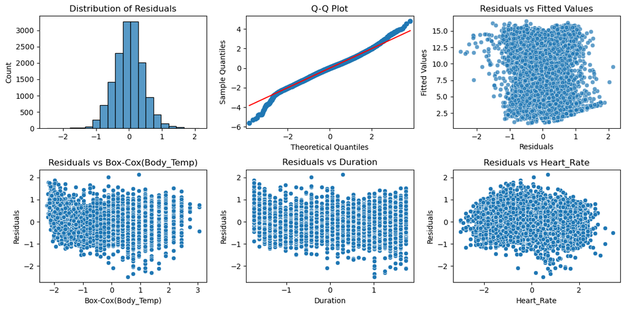

```python
residual_plots(X_transformed, y_sqrt, ['boxcox__Body_Temp','num__Duration', 'num__Heart_Rate'])
```

It is clear from the distribution of the residuals and the Q-Q plot that a linear regression based on the transformed data results in more normalised residuals. The plots of Residuals vs Fitted Values and features no longer display the patterns seen with the un-transformed data so these transformations have had the desired effect of normalising the residuals and linearising the relationships between features and target.

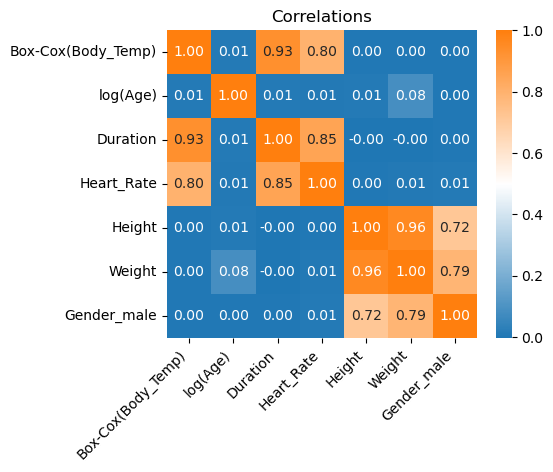

```python
plot_correlation_matrix(X_transformed)
```

```python
results = display_coefs(X_transformed, y_sqrt)
```

Linear Regression Coefficients

|  | Coeff | P-values | VIF |
| --- | --- | --- | --- |
| const | 8.882858 | 0.000000e+00 | NaN |
| Duration | 2.425509 | 0.000000e+00 | 10.134767 |
| Heart_Rate | 1.007092 | 0.000000e+00 | 3.666201 |
| log(Age) | 0.410059 | 0.000000e+00 | 1.108861 |
| Weight | 0.331154 | 7.171541e-99 | 18.585574 |
| Gender_male | -0.227256 | 4.426028e-77 | 2.831761 |
| Height | -0.215143 | 1.812084e-55 | 14.291200 |
| Box-Cox(Body_Temp) | 0.181628 | 8.669282e-74 | 7.570772 |

We can see two highly correllated groups - `Height`/`Weight` and `Duration`/`Body_Temp`/`Heart_Rate`. The highest correlated and highest VIFs correspond to the `Height`/`Weight` pair. How we deal with these is a trade off between interpretability and predictive accuracy. In the first section we will focus on interpretability.

### Feature Engineering for interpretability

Body Mass Index (BMI) is a widely adopted metric in health for assessing body composition. It is an ideal candidate for combining `Height` and `Weight` into one interpretable feature. We will perform this transformation and evaluate it's impact on the model.

```python
# Now the BMI
class HeightWeightTransformer(BaseEstimator, TransformerMixin):
    """
    A custom transformer that calculates BMI column from Height and Weight columns and drops Height and Weight
    """

    # for compatibility with scikit-learn API
    def fit(self, X, y=None):
        return self

    def transform(self, X):
        """
        Args:
            X(pd.DataFrame): Input DataFrame

        Returns:
            pd.DataFrame: Replaces Height and Weight with BMI.
        """
        X_ = X.copy()
        X_['BMI'] = X_['Weight']/(X_['Height']**2)
        X_ = X_.drop(columns=['Height', 'Weight'])
        return X_

preprocessor = ColumnTransformer([
    ('boxcox', boxcox_transformer, ['Body_Temp']),
    ('log', age_pipeline, ['Age']),
    ('num', StandardScaler(), ['Duration', 'Heart_Rate', 'BMI']),
    ('cat', cat_pipeline, ['Gender'])],
    remainder='passthrough').set_output(transform="pandas")

bmi_pipeline = Pipeline([
    ('size', HeightWeightTransformer()),
    ('preprocessor', preprocessor),

])

X = df.copy()
X.pop('Calories')
X_transformed = bmi_pipeline.fit_transform(X)
```

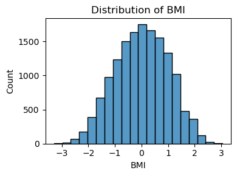

```python
plt.figure(figsize=(4, 3))

sns.histplot(
        data=X_transformed,
        x='num__BMI',
        bins = 20,
    )
plt.xlabel("BMI")
plt.title('Distribution of BMI')
plt.tight_layout()
plt.show()
```

```python
bmi_regression_pipeline = Pipeline(bmi_pipeline.steps + [
    ('regression', sqrt_target_regressor)])

X = df.copy()
y = X.pop("Calories")
display_scores(X, y, bmi_regression_pipeline)
```

Cross-Validated Performance Metrics (5-Fold)

| R-squared | R-squared std | RMSE | RMSE std |
| --- | --- | --- | --- |
| 0.979643 | 0.000861 | -79.337598 | 2.778870 |

```python
# update the BMI alias
feature_aliases.update({'num__BMI': 'BMI'})
display_coefs(X_transformed, y_sqrt)
```

Linear Regression Coefficients

|  | Coeff | P-values | VIF |
| --- | --- | --- | --- |
| const | 8.806924 | 0.000000e+00 | NaN |
| Duration | 2.424545 | 0.000000e+00 | 10.133232 |
| Heart_Rate | 1.007441 | 0.000000e+00 | 3.666165 |
| log(Age) | 0.424939 | 0.000000e+00 | 1.113746 |
| Box-Cox(Body_Temp) | 0.182120 | 5.773804e-72 | 7.569415 |
| Gender_male | -0.074162 | 1.565875e-13 | 1.870065 |
| BMI | 0.045012 | 3.509678e-18 | 1.985226 |

We can see that `BMI` is approximately normally distributed.  
The R-squared score is **0.0007** lower than the model with `Height` and `Weight`, which is not significant and the VIF of the new feature is now below the threshold. The combination of `Height` and `Weight` into `BMI` has solved the collinearity problem without meaningfully affecting model accuracy.

Now we turn our attention to the correlated `Duration`, `Heart_Rate` and `Body_Temp` features. There is no obvious interpretable comnination of these 3 features so we could consider dropping one or more of these features. Although `Duration` has the larger coefficient of the 3 it also has the highest VIF which indicates the coefficient is the most unstable. The best choice here is to drop `Duration` and re-evaluate the model.

```python
# score dropped duration model
drop_duration_regression_pipeline = Pipeline([
    ('size', HeightWeightTransformer()),
    ('preprocessor', preprocessor),
    ('regressor', sqrt_target_regressor),
])
display_scores(X, y, drop_duration_regression_pipeline)
```

Cross-Validated Performance Metrics (5-Fold)

| R-squared | R-squared std | RMSE | RMSE std |
| --- | --- | --- | --- |
| 0.979643 | 0.000861 | -79.337598 | 2.778870 |

```python
#Drop Duration
preprocessor = ColumnTransformer([
    ('boxcox', boxcox_transformer, ['Body_Temp']),
    ('log', age_pipeline, ['Age']),
    ('num', StandardScaler(), ['BMI', 'Heart_Rate']),
    ('cat', cat_pipeline, ['Gender'])],
    remainder='drop').set_output(transform="pandas") # drops remainder i.e. 'Duration'

drop_duration_pipeline = Pipeline([
    ('size', HeightWeightTransformer()),
    ('preprocessor', preprocessor),
])
X = df.copy()
X.pop('Calories')
X_transformed = drop_duration_pipeline.fit_transform(X)

display_coefs(X_transformed, y_sqrt)
```

Linear Regression Coefficients

|  | Coeff | P-values | VIF |
| --- | --- | --- | --- |
| const | 8.818081 | 0.000000 | NaN |
| Box-Cox(Body_Temp) | 1.856278 | 0.000000 | 2.737932 |
| Heart_Rate | 1.741213 | 0.000000 | 2.738032 |
| log(Age) | 0.422926 | 0.000000 | 1.113739 |
| Gender_male | -0.096657 | 0.000001 | 1.869847 |
| BMI | 0.045662 | 0.000007 | 1.985225 |

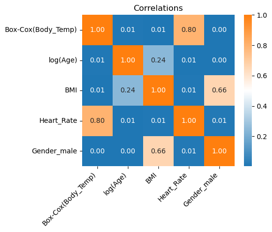

```python
plot_correlation_matrix(X_transformed)
```

```python
X_reduced = X_transformed.drop(columns=['num__Heart_Rate'])
display_coefs(X_reduced, y_sqrt)
```

Linear Regression Coefficients

|  | Coeff | P-values | VIF |
| --- | --- | --- | --- |
| const | 8.805058 | 0.000000e+00 | NaN |
| Box-Cox(Body_Temp) | 3.243458 | 0.000000e+00 | 1.000131 |
| log(Age) | 0.416136 | 7.188662e-260 | 1.113697 |
| Gender_male | -0.070401 | 2.184287e-02 | 1.869691 |
| BMI | 0.049250 | 1.849299e-03 | 1.985213 |

Dropping `Heart_Rate` has the affect of adding to the strength of coefficient of `Body_Temp`, as would be expected since `Heart_Rate` is no longer contributing. All other features coefficients are virtually unchanged. Together with the significant p-values and low VIF's this suggests there is no problem with multicollinearity, so we should retain `Heart Rate`.

#### Final Model for Interpretability

The numerical predictors, in order of decreasing magnitude are `Body_Temp`, `Heart_Rate`, `Age`, `BMI`. These all have positive coefficents which means higher values of any of these would lead to higher predictions for `Calories`. However, it should be noted that there is no claim that the relationships are linear, in fact non-linearity is evident for all feature-target relationships, in their original measurement scales.  
The `Gender` effect is that `Male` would be expected to burn less `Calories` than `Female` to some extent.

### Feature Engineering for Model Prediction Accuracy

#### `Height` and `Weight`

In the previous section, to address multicollinearity between `Height` and `Weight` we combined these features into an easily interpretable `BMI` feature, accepting a slight reduction in predictive accuracy. We can instead use Principal Component Analysis (PCA)<sup>[ⓘ](https://en.wikipedia.org/wiki/Principal_component_analysis)</sup> to address multicollinearity while preserving predictive accuracy. The downside of this technique is loss of interpretability. We will now create principal components for `Height`/`Weight` and assess their impact on the model. We will refer to `Height` and `Weight` as the `size` features.

```python
size_cols = ['Height', 'Weight']
size_pca_processor = Pipeline([('scaler', StandardScaler()), ('pca', PCA(n_components=2))])

preprocessor = ColumnTransformer([
    ('boxcox', boxcox_transformer, ['Body_Temp']),
    ('log', age_pipeline, ['Age']),
    ('num', StandardScaler(), ['Duration', 'Heart_Rate']),
    ('cat', cat_pipeline, ['Gender']),
    ('size', size_pca_processor, size_cols)],
    remainder='drop').set_output(transform="pandas")

size_pca_pipeline = Pipeline([
    ('preprocessor', preprocessor),
    ('regression', transformed_target_regressor),
])
X = df.copy()
X.pop('Calories')
X_transformed = pd.DataFrame(size_pca_pipeline.named_steps['preprocessor'].fit_transform(X))
display_coefs(X_transformed, y_sqrt)
```

Linear Regression Coefficients

|  | Coeff | P-values | VIF |
| --- | --- | --- | --- |
| const | 8.882858 | 0.000000e+00 | NaN |
| Duration | 2.425509 | 0.000000e+00 | 10.134767 |
| Heart_Rate | 1.007092 | 0.000000e+00 | 3.666201 |
| log(Age) | 0.410059 | 0.000000e+00 | 1.108861 |
| size__pca1 | 0.386290 | 6.320025e-80 | 1.289456 |
| Gender_male | -0.227256 | 4.426028e-77 | 2.831761 |
| Box-Cox(Body_Temp) | 0.181628 | 8.669282e-74 | 7.570772 |
| size__pca0 | 0.082032 | 9.162793e-84 | 2.652835 |

```python
display_scores(X, y, size_pca_pipeline)
```

Cross-Validated Performance Metrics (5-Fold)

| R-squared | R-squared std | RMSE | RMSE std |
| --- | --- | --- | --- |
| 0.980334 | 0.000752 | -76.652708 | 2.531216 |

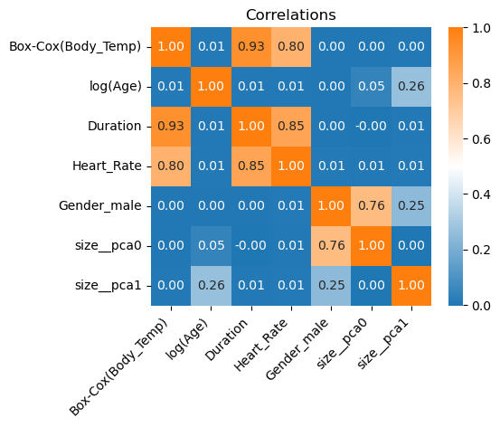

```python
plot_correlation_matrix(X_transformed)
```

```python
def display_evrs(pca_model, pc_names, orig_features):
    display(Markdown('''#### Explained Variance ratios and Loadings'''))
    components = [row.tolist() for row in pca_model.components_]
    explained_variance_ratio = pca_model.explained_variance_ratio_
    cumulative_explained_variance = explained_variance_ratio.cumsum()
    pca_df = pd.DataFrame(
        components,
        columns=orig_features,
    )
    evrs_df = pd.DataFrame({'Explained variance (%)':explained_variance_ratio *100,
                        'Cumulative explained variance (%)':cumulative_explained_variance*100})

    final_df = pd.concat([evrs_df, pca_df], axis=1)
    final_df.index=pc_names
    display(final_df)

preprocessor_step = size_pca_pipeline.named_steps['preprocessor']
pca_pipeline_for_size = preprocessor_step.named_transformers_['size']
pca_model_for_size = pca_pipeline_for_size.named_steps['pca']
display_evrs(pca_model_for_size, ['size__pca0', 'size__pca1'], ['Height', 'Weight'])
```

Explained Variance ratios and Loadings

|  | Explained variance (%) | Cumulative explained variance (%) | Height | Weight |
| --- | --- | --- | --- | --- |
| size__pca0 | 97.954716 | 97.954716 | 0.707107 | 0.707107 |
| size__pca1 | 2.045284 | 100.000000 | -0.707107 | 0.707107 |

As expected, the principal components `size__pca0` and `size__pca1` are uncorrelated. The corresonding VIFs are now acceptible. PCA has succeeded in addressing multicollinearity between `Height` and `Weight` without sacrificing any predictive accuracy (as expected, R2 and RMSE are the same). We can see that the first component accounts for almost 98% of the variance in `Height` and `Weight` and the second 2%. It's important to understand though, that because principal components have differing variances, it's not possible to directly compare regression coefficients as we can with the original features. The coefficient of `size__pca0` is close to zero, meaning that it has very little predictive power, and although `size__pca1` has a larger coefficient, it accounts for very little variance in the original features, so also has very little predictive power.

We will now use the same technique to address multicollinearity between `Duration`, `Heart_Rate` and `Box-Cox(Body_Temp)`, which we will refer to as the `effort` features.

#### `Duration`, `Heart_Rate` and `Box-Cox(Body_Temp)`

```python
base_pca_processor = Pipeline([
    # apply Box_Cox transformation to 'Body_Temp'
    ('individual_feature_prep', make_column_transformer(
        (PowerTransformer(method='box-cox', standardize=False), ['Body_Temp']),
        # Pass through 'Duration' and 'Heart_Rate'
        remainder='passthrough',
    )),
    # scale Box_Cox(Body_Temp), Duration, Heart_Rate
    ('scaler', StandardScaler()),
])

effort_pca_processor = Pipeline(base_pca_processor.steps + [('pca', PCA(n_components=3))])
effort_cols = ['Duration', 'Body_Temp', 'Heart_Rate']

preprocessor = ColumnTransformer([
    ('log', age_pipeline, ['Age']),
    ('cat', cat_pipeline, ['Gender']),
    ('effort', effort_pca_processor, effort_cols),
    ('size', size_pca_processor, size_cols)],
    remainder='drop').set_output(transform="pandas")

effort_pca_pipeline = Pipeline([
    ('preprocessor', preprocessor),
])

X = df.copy()

X.pop('Calories')
X_transformed = effort_pca_pipeline.fit_transform(X)
```

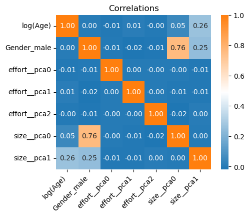

```python
plot_correlation_matrix(X_transformed)
```

```python
X = add_constant(X_transformed, prepend=True)
display_coefs(X, y_sqrt)
```

Linear Regression Coefficients

|  | Coeff | P-values | VIF |
| --- | --- | --- | --- |
| const | 8.882858 | 0.000000e+00 | NaN |
| effort__pca0 | -2.104306 | 0.000000e+00 | 1.000139 |
| effort__pca2 | 1.575476 | 0.000000e+00 | 1.000347 |
| log(Age) | 0.410059 | 0.000000e+00 | 1.108861 |
| size__pca1 | 0.386290 | 6.320025e-80 | 1.289456 |
| Gender_male | -0.227256 | 4.426028e-77 | 2.831761 |
| effort__pca1 | -0.141738 | 7.498299e-74 | 1.000349 |
| size__pca0 | 0.082032 | 9.162793e-84 | 2.652835 |

```python
# explained_variance_ratios
preprocessor_step = effort_pca_pipeline.named_steps['preprocessor']
pca_pipeline_for_effort = preprocessor_step.named_transformers_['effort']
pca_model_for_effort = pca_pipeline_for_effort.named_steps['pca']
display_evrs(pca_model_for_effort, ['effort__pca0', 'effort__pca1', 'effort__pca2'], ['Box-Cox(Body_Temp)', 'Duration', 'Heart_Rate'])
```

Explained Variance ratios and Loadings

|  | Explained variance (%) | Cumulative explained variance (%) | Box-Cox(Body_Temp) | Duration | Heart_Rate |
| --- | --- | --- | --- | --- | --- |
| effort__pca0 | 90.727661 | 90.727661 | -0.579442 | -0.591285 | -0.560919 |
| effort__pca1 | 7.238854 | 97.966515 | 0.540472 | 0.236364 | -0.807479 |
| effort__pca2 | 2.033485 | 100.000000 | -0.610031 | 0.771048 | -0.182613 |

### Interactions

It's possible that there are interactions between features which could prove useful in predicting target values. `Gender` is an obvious choice due to potential differences bewteen effects of **male** and **female**. In order to find likely candidates we will look at scatterplots of features vs target colour coded by `Gender`.

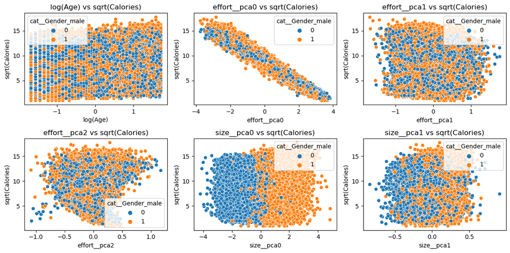

```python
# Scatterplots
X = df.copy()
X.pop('Calories')
X_transformed = effort_pca_pipeline.named_steps['preprocessor'].fit_transform(X)
X_transformed['sqrt_Calories'] = y_sqrt

features = ['log__Age', 'effort__pca0',
       'effort__pca1', 'effort__pca2',
       'size__pca0', 'size__pca1']

grid = PlotGrid(len(features))

for i, feature in enumerate(features):
    axis = grid.get_axis(i)
    name = feature_aliases.get(feature) or feature
    sns.scatterplot(x=X_transformed[feature], y=X_transformed['sqrt_Calories'], hue=X_transformed['cat__Gender_male'], ax=axis)
    axis.set_title(f"{name} vs {'sqrt(Calories)'}")
    axis.set_xlabel(name)
    axis.set_ylabel('sqrt(Calories)')

grid.show()
```

The plot `effort__pca0` vs `sqrt(Calories)` suggests there may be a difference in slope between **male** and **female**. We will create a new feature which is the product of `effort__pca0` and `Gender__male` and evaluate it's effect on the predictions.

```python
def create_interaction(dataframe):
    """
    Creates an interaction (product) between 'cat__Gender_male' and 'effort__pca0'
    """
    df_copy = dataframe.copy()
    df_copy["Gender_x_effort__pca0"] = df_copy['cat__Gender_male'] * df_copy['effort__pca0']
    return df_copy

preprocessor = ColumnTransformer([
    ('log', age_pipeline, ['Age']),
    ('cat', cat_pipeline, ['Gender']),
    ('effort', effort_pca_processor, effort_cols),
    ('size', size_pca_processor, size_cols),
    ], remainder='drop').set_output(transform="pandas")

interaction_regression_pipeline = Pipeline([
    ('preprocessor', preprocessor),
    ('interaction_adder', FunctionTransformer(func=create_interaction, validate=False)),
    ('regressor', transformed_target_regressor),
    ])
X = df.copy()
display_scores(X, y, interaction_regression_pipeline)
```

Cross-Validated Performance Metrics (5-Fold)

| R-squared | R-squared std | RMSE | RMSE std |
| --- | --- | --- | --- |
| 0.983569 | 0.000886 | -64.036679 | 3.112003 |

```python
# create a transformation pipeline (previous pipeline minus the regressor)
interaction_transformation_pipeline = Pipeline([
    ('preprocessor', preprocessor),
    ('interaction_adder', FunctionTransformer(func=create_interaction, validate=False)),
])
X_transformed = interaction_transformation_pipeline.fit_transform(X)
display_coefs(X_transformed, y_sqrt)
```

Linear Regression Coefficients

|  | Coeff | P-values | VIF |
| --- | --- | --- | --- |
| const | 8.882474 | 0.000000e+00 | NaN |
| effort__pca0 | -2.015310 | 0.000000e+00 | 1.970536 |
| effort__pca2 | 1.577151 | 0.000000e+00 | 1.000354 |
| log(Age) | 0.411031 | 0.000000e+00 | 1.108903 |
| size__pca1 | 0.389546 | 3.021689e-91 | 1.289475 |
| Gender_male | -0.228143 | 3.100607e-87 | 2.831770 |
| Gender_x_effort__pca0 | -0.180718 | 0.000000e+00 | 1.970341 |
| effort__pca1 | -0.142801 | 3.727710e-84 | 1.000360 |
| size__pca0 | 0.082274 | 1.245539e-94 | 2.652840 |

It is clear that the interaction term holds some predictive power and the R-squared score is slightly improved, with the coefficient being highly significant and VIF acceptable. Model performance has been slightly improved without the introduction of multicollinearity.  
At this point we could iterate through features pairwise, create interaction terms and evaluate models to find out if any further interaction terms are of use. However, since we already have a very accurate model (**R-Squared = 0.984**) there is little room to improve the model further.

### Conclusion

The final model for interpretability is likely to provide the clearest insight into the relationships between predictors and the target. The final model for predictive accuracy has achieved an improvement in peformance. However, this report restricted modelling to linear regression only. There are other regression models we could apply which may improve predictive accuracy further.

- Regularized Linear Models (such as Ridge Regression, Lasso Regression and Elastic Net) can handle multicollinearity and may offer improvements in predictive performance.
- Tree-Based Models such as Random Forest Regression and Gradient Boosted Machines often out perform Regularized Linear Models.